# Quiz 2

Chris Moroney

2020-11-02

```r
library(tidyverse)
library(openintro)
revenue <-read_csv("https://bit.ly/385faPm")
```

### Question 1 a

```r
revenue %>%
  pivot_longer(c(Qtr_1, Qtr_2, Qtr_3, Qtr_4), names_to="Quarter", values_to="Revenue")
```

```
## # A tibble: 48 x 4
##    Group  Year Quarter Revenue
##    <chr> <dbl> <chr>     <dbl>
##  1 A      2015 Qtr_1        15
##  2 A      2015 Qtr_2        16
##  3 A      2015 Qtr_3        19
##  4 A      2015 Qtr_4        17
##  5 A      2016 Qtr_1        12
##  6 A      2016 Qtr_2        13
##  7 A      2016 Qtr_3        27
##  8 A      2016 Qtr_4        23
##  9 A      2017 Qtr_1        22
## 10 A      2017 Qtr_2        22
## # … with 38 more rows
```

### Question 1 b

```r
revenue %>%
  pivot_longer(c(Qtr_1, Qtr_2, Qtr_3, Qtr_4), names_to="Quarter", values_to="Revenue") %>%
  group_by(Group, Year) %>%
  summarize(annual_revenue = sum(Revenue)) %>%
  arrange(Year, desc(annual_revenue))
```

```
## # A tibble: 12 x 3
## # Groups:   Group [3]
##    Group  Year annual_revenue
##    <chr> <dbl>          <dbl>
##  1 B      2015             68
##  2 A      2015             67
##  3 C      2015             61
##  4 A      2016             75
##  5 C      2016             72
##  6 B      2016             70
##  7 A      2017             88
##  8 C      2017             71
##  9 B      2017             68
## 10 B      2018             89
## 11 C      2018             78
## 12 A      2018             60
```

### Question 1 c

```r
# Used this to reproduce required dataframe
revenue2 <- revenue %>%
  rename('1'=Qtr_1, '2'=Qtr_2, '3'=Qtr_3, '4'=Qtr_4) %>%
  pivot_longer('1':'4', names_to="Column", values_to="Revenue") %>%
  unite(Year_Quarter, Year, Column) %>%
  arrange(Year_Quarter)
revenue2
```

```
## # A tibble: 48 x 3
##    Group Year_Quarter Revenue
##    <chr> <chr>          <dbl>
##  1 A     2015_1            15
##  2 B     2015_1            12
##  3 C     2015_1            11
##  4 A     2015_2            16
##  5 B     2015_2            13
##  6 C     2015_2            12
##  7 A     2015_3            19
##  8 B     2015_3            25
##  9 C     2015_3            22
## 10 A     2015_4            17
## # … with 38 more rows
```

```r
# Using this as assurance
revenue2 <-read_csv("https://bit.ly/3jQK00e")
```

### Question 1 d

```r
library(zoo)
revenue2 <-mutate(revenue2, Year_Quarter=as.yearqtr(Year_Quarter))
```

### Question 1 e

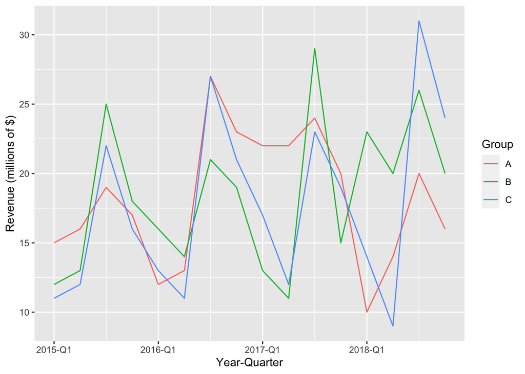

```r
ggplot(data=revenue2, mapping=aes(x=Year_Quarter, y=Revenue)) +
  geom_line(mapping=aes(color=Group)) +
  scale_x_yearqtr(format = "%Y-Q%q") +
  xlab("Year-Quarter") +
  ylab("Revenue (millions of $)")
```

### Question 2 a

```r
library(nycflights13)
NYCdestinations <- nycflights %>%
  filter(year==2013) %>%
  group_by(year) %>%
  summarize(total_flights = n(), mean_arrival = mean(arr_delay), mean_dist = mean(distance))
```

### Question 2 b

The 5 destinations with the given conditions are Nashville Intl, Chicago Midway Intl, Harsfield Jackson Atlanta Intl, Washington Dulles Intl, and Cleveland Hopkins Intl

```r
nycflights %>%
  filter(year==2013) %>%
  group_by(dest) %>%
  summarize(total_flights = n(), mean_arr = mean(arr_delay)) %>%
  filter(total_flights >= 365) %>%
  left_join(airports, by=c('dest' = 'faa')) %>%
  select(dest, name, total_flights, mean_arr) %>%
  arrange(desc(mean_arr)) %>%
  head(5)
```

```
## # A tibble: 5 x 4
##   dest  name                            total_flights mean_arr
##   <chr> <chr>                                   <int>    <dbl>
## 1 BNA   Nashville Intl                            557     17.4
## 2 MDW   Chicago Midway Intl                       437     11.9
## 3 ATL   Hartsfield Jackson Atlanta Intl          1653     11.7
## 4 IAD   Washington Dulles Intl                    535     11.5
## 5 CLE   Cleveland Hopkins Intl                    415     11.3
```

### Question 2 c

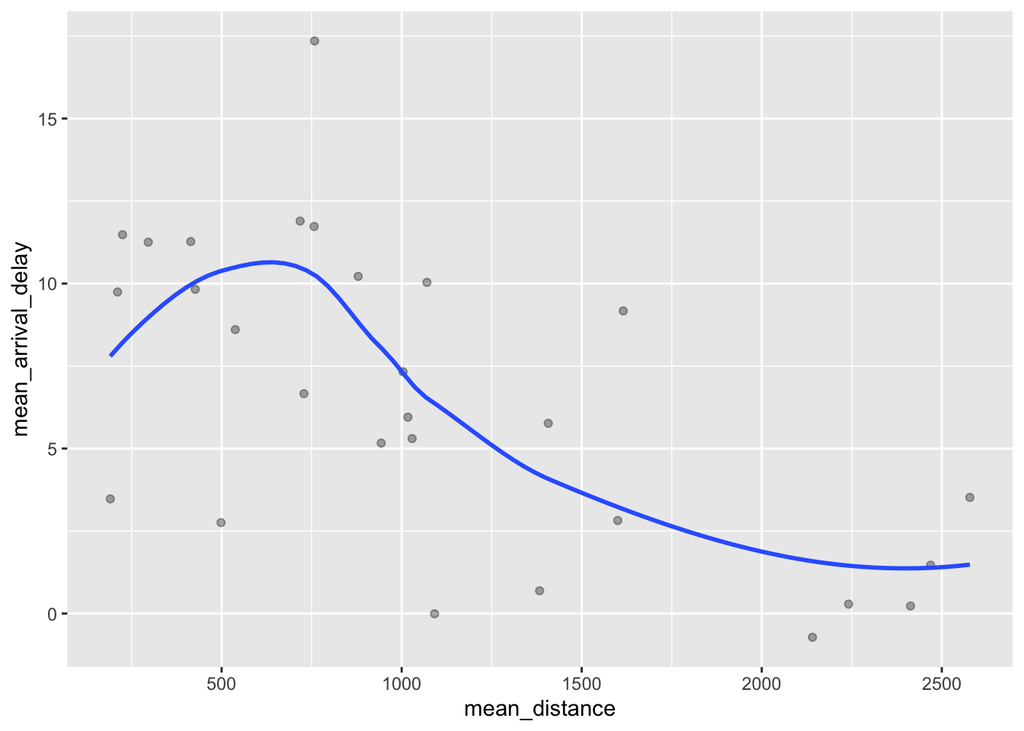

```r
graphdata <- nycflights %>%
  filter(year==2013) %>%
  group_by(dest) %>%
  summarize(total_flights = n(), mean_arrival_delay = mean(arr_delay), mean_distance = mean(distance)) %>%
  filter(total_flights >= 365)
ggplot(data=graphdata, mapping=aes(x=mean_distance,y=mean_arrival_delay)) +
  geom_point(alpha=1/3) +
  geom_smooth(se=FALSE)
```

### Question 2 d

The outlier airport is BNA, which is the Nashville Intl airport (information from the airports dataframe)

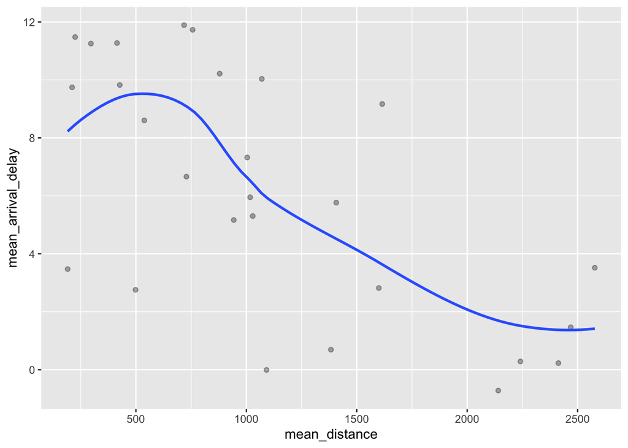

```r
newgraphdata <- nycflights %>%
  filter(year==2013) %>%
  group_by(dest) %>%
  summarize(total_flights = n(), mean_arrival_delay = mean(arr_delay), mean_distance = mean(distance)) %>%
  filter(total_flights >= 365) %>%
  filter(mean_arrival_delay < 15)
ggplot(data=newgraphdata, mapping=aes(x=mean_distance,y=mean_arrival_delay)) +
  geom_point(alpha=1/3) +
  geom_smooth(se=FALSE)
```

### Question 2 e

What I am noticing in general between both graphs is that as the mean distance increases, the mean arrival delay will decrease. However, between around 200 and 500 miles, the arrival delay actually increases slightly from 8 minutes to 10 minutes, but then for distances greater than 500 miles, the mean arrival time decreases significantly from about 10 minutes to just under 2 minutes. A possible explanation for this is that for flights that have to travel longer distances, there could a greater chance of hazardous weather that could disrupt the flight. This means that the flight would have to follow a more strict time frame in order to avoid the hazardous weather, which could include leaving sooner than anticipated times. For shorter flights, the time frame may not always be as strict, which means that the time frame of arriving could vary more since careful planning of other hazards may not be necessary. There could be other possibilities such as shorter flights being more likely to be canceled or changed than longer flights, which means that flights may arrive at later times.